# Retail Revenue Forecasting: reconciliation, residual tests and calibration (R report)

M5 Walmart weekly revenue, 154-node hierarchy, rolling-origin backtest, 4-week horizon

## What this report covers

The R side of the project: `fable` ETS (on an STL seasonally adjusted series) and dynamic harmonic regression ARIMA (four Fourier pairs, period 52) fitted on all 154 nodes of the M5 hierarchy (3 states, 10 stores, 3 categories, 7 departments and their crossings), refitted at 12 rolling origins (6 validation, 6 test), then reconciled with bottom-up, OLS, WLS (structural and variance) and MinT shrinkage. Top-down methods need a strict hierarchy, so they are evaluated on the geographic sub-hierarchy Total > State > Store > Store x Department (84 nodes). Every forecast, R or Python, is scored by the same Python metric code, so the tables below are directly comparable with the Python models. The test window is the last six origins (weeks 254 to 277) and was not used for any choice.

## Accuracy before and after reconciliation (test window, WAPE)

WAPE (%) by hierarchy level, R fable base forecasts and reconciled forecasts

| base_model | method | Total | State | Store | Category | Dept | State x Cat | State x Dept | Store x Cat | Store x Dept |
| --- | --- | --- | --- | --- | --- | --- | --- | --- | --- | --- |
| R ETS | base (unreconciled) | 3.26 | 3.92 | 4.64 | 4.52 | 5.14 | 5.02 | 5.79 | 6.00 | 7.04 |
| R ETS | bottom-up | 3.59 | 4.02 | 4.71 | 4.44 | 5.16 | 5.01 | 5.80 | 5.93 | 7.04 |
| R ETS | MinT shrink | 3.48 | 3.87 | 4.62 | 4.46 | 5.15 | 4.95 | 5.77 | 5.90 | 6.99 |
| R ETS | OLS | 3.41 | 3.84 | 4.63 | 4.41 | 5.08 | 4.96 | 5.74 | 5.90 | 7.07 |
| R ETS | WLS structural | 3.54 | 3.95 | 4.68 | 4.44 | 5.13 | 5.00 | 5.77 | 5.93 | 7.06 |
| R ETS | WLS variance | 3.55 | 3.97 | 4.69 | 4.43 | 5.14 | 4.99 | 5.77 | 5.93 | 7.04 |
| R ARIMA | base (unreconciled) | 3.06 | 3.41 | 4.56 | 3.63 | 4.78 | 5.22 | 5.64 | 6.03 | 6.97 |
| R ARIMA | bottom-up | 3.75 | 4.26 | 4.81 | 4.47 | 4.86 | 5.06 | 5.68 | 5.98 | 6.97 |
| R ARIMA | MinT shrink | 2.67 | 3.23 | 3.99 | 3.30 | 3.96 | 4.00 | 4.80 | 5.23 | 6.33 |
| R ARIMA | OLS | 3.12 | 3.54 | 4.27 | 3.74 | 4.51 | 4.72 | 5.67 | 5.84 | 7.14 |
| R ARIMA | WLS structural | 3.35 | 3.82 | 4.52 | 4.01 | 4.57 | 4.76 | 5.51 | 5.80 | 6.91 |
| R ARIMA | WLS variance | 3.44 | 3.87 | 4.57 | 4.06 | 4.54 | 4.70 | 5.39 | 5.74 | 6.77 |

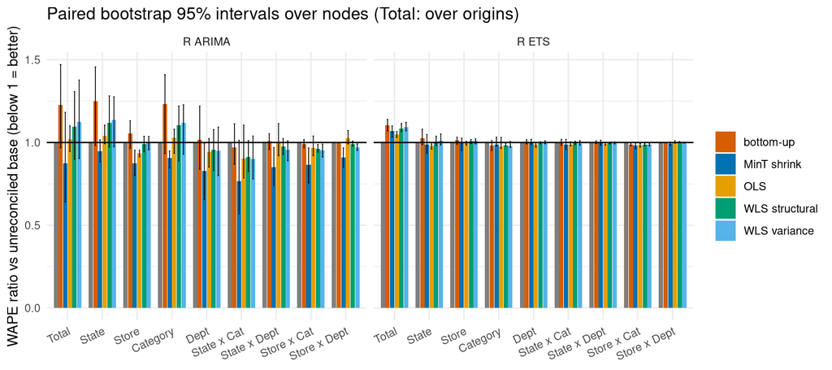

### Top-down on the geographic sub-hierarchy (levels 1, 2, 3, 9)

WAPE (%), 84-node geographic hierarchy

| base_model | method | Total | State | Store | Store x Dept |
| --- | --- | --- | --- | --- | --- |
| R ETS | bottom-up | 3.59 | 4.02 | 4.71 | 7.04 |
| R ETS | MinT shrink | 3.48 | 3.89 | 4.64 | 7.00 |
| R ETS | OLS | 3.33 | 3.77 | 4.59 | 7.02 |
| R ETS | top-down (average proportions) | 3.26 | 5.36 | 11.05 | 16.62 |
| R ETS | top-down (forecast proportions) | 3.26 | 3.77 | 4.58 | 6.98 |
| R ETS | base (unreconciled) | 3.26 | 3.92 | 4.64 | 7.04 |
| R ARIMA | bottom-up | 3.75 | 4.26 | 4.81 | 6.97 |
| R ARIMA | MinT shrink | 3.20 | 3.49 | 4.08 | 6.44 |
| R ARIMA | OLS | 3.05 | 3.44 | 4.20 | 7.18 |
| R ARIMA | top-down (average proportions) | 3.06 | 5.57 | 11.23 | 16.69 |
| R ARIMA | top-down (forecast proportions) | 3.06 | 3.48 | 4.23 | 6.72 |
| R ARIMA | base (unreconciled) | 3.06 | 3.41 | 4.56 | 6.97 |

## Incoherence of base forecasts

Mean absolute gap between a node’s base forecast and the sum of its bottom-level forecasts (% of the node forecast)

| model | Total | State | Store | Category | Dept | State x Cat | State x Dept | Store x Cat | Store x Dept |
| --- | --- | --- | --- | --- | --- | --- | --- | --- | --- |
| ets | 1.37 | 1.25 | 1.38 | 1.42 | 2.85 | 2.24 | 2.71 | 1.05 | 0 |
| lgbm_q | 1.17 | 1.24 | 1.21 | 0.99 | 1.45 | 1.09 | 1.35 | 0.87 | 0 |
| r_arima_base | 1.88 | 2.23 | 1.98 | 1.41 | 2.10 | 1.22 | 1.86 | 0.99 | 0 |
| r_ets_base | 0.43 | 0.36 | 0.46 | 0.25 | 0.49 | 0.40 | 0.52 | 0.34 | 0 |
| sarima_airline | 0.67 | 0.79 | 0.72 | 0.60 | 1.30 | 0.65 | 1.02 | 0.47 | 0 |

## Residual tests

Ljung-Box (lag 52, no degrees-of-freedom adjustment, so slightly conservative towards not rejecting) on the innovation residuals of the fit at the last test origin (273 weeks of training), and Shapiro-Wilk for the normality that Gaussian intervals rely on. The ETS component model has 52 missing residuals at the start (STL warm-up), which are dropped.

Share of nodes rejecting at 5 percent, by model and level

| model | level | n_nodes | share_ljung_box_rejected | median_ljung_box_p | median_lag1_acf | share_shapiro_rejected |
| --- | --- | --- | --- | --- | --- | --- |
| arima | Total | 1 | 1.000 | 0.000 | -0.005 | 0.000 |
| arima | State | 3 | 1.000 | 0.000 | 0.001 | 0.333 |
| arima | Store | 10 | 0.900 | 0.000 | -0.046 | 0.300 |
| arima | Category | 3 | 1.000 | 0.000 | -0.020 | 0.333 |
| arima | Dept | 7 | 1.000 | 0.000 | -0.019 | 0.429 |
| arima | State x Cat | 9 | 0.889 | 0.000 | 0.006 | 0.333 |
| arima | State x Dept | 21 | 0.905 | 0.000 | -0.005 | 0.667 |
| arima | Store x Cat | 30 | 0.700 | 0.000 | -0.004 | 0.400 |
| arima | Store x Dept | 70 | 0.829 | 0.000 | -0.002 | 0.586 |
| ets | Total | 1 | 1.000 | 0.000 | 0.162 | 0.000 |
| ets | State | 3 | 0.667 | 0.000 | 0.109 | 0.333 |
| ets | Store | 10 | 0.700 | 0.010 | 0.060 | 0.300 |
| ets | Category | 3 | 0.333 | 0.137 | 0.009 | 0.000 |
| ets | Dept | 7 | 0.571 | 0.002 | 0.105 | 0.429 |
| ets | State x Cat | 9 | 0.556 | 0.022 | 0.040 | 0.444 |
| ets | State x Dept | 21 | 0.667 | 0.017 | 0.062 | 0.381 |
| ets | Store x Cat | 30 | 0.633 | 0.027 | 0.021 | 0.333 |
| ets | Store x Dept | 70 | 0.657 | 0.016 | 0.050 | 0.343 |

## Interval calibration (test window)

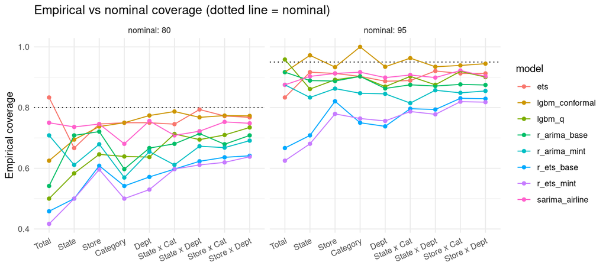

## fabletools accuracy (R-native cross-check)

fabletools::accuracy, mean over all 154 nodes and test origins (unweighted, so dominated by small nodes)

| base_model | recon | MASE | RMSSE | CRPS |
| --- | --- | --- | --- | --- |
| arima | base | 1.146 | 0.994 | 1823.218 |
| arima | bu | 1.156 | 1.004 | 2087.684 |
| arima | mint | 1.074 | 0.927 | 1586.443 |
| arima | ols | 1.351 | 1.186 | 1863.365 |
| arima | wls_struct | 1.175 | 1.024 | 2033.881 |
| arima | wls_var | 1.129 | 0.978 | 2077.463 |
| ets | base | 1.122 | 0.978 | 1959.389 |
| ets | bu | 1.124 | 0.978 | 2109.208 |
| ets | mint | 1.115 | 0.972 | 1957.805 |
| ets | ols | 1.128 | 0.982 | 2072.280 |
| ets | wls_struct | 1.121 | 0.976 | 2214.097 |
| ets | wls_var | 1.121 | 0.977 | 2256.373 |